# BIO_1007A Web Page

Abigail Griffin

2023-02-03

## Welcome to my GitHub!

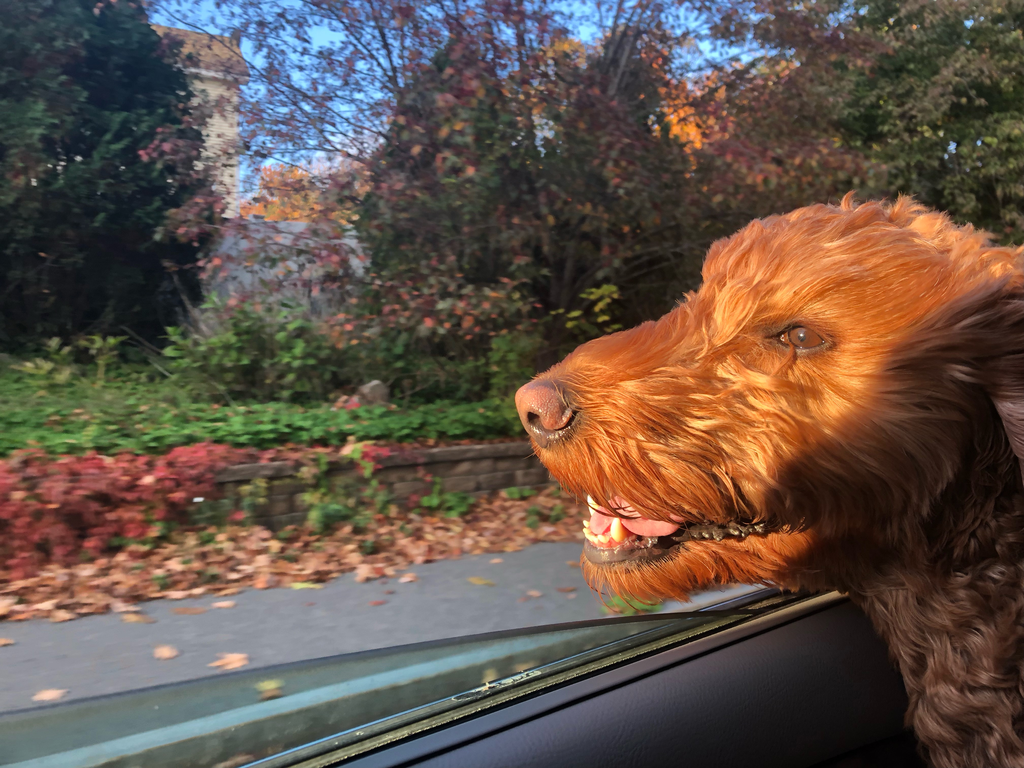

My name is Abby Griffin (she/her) and I am a student in Reproducible Biology in R, a Winter Term course at Middlebury College taught by Professor Ash. I am a member of the class of 2023 studying Neuroscience and Sociology. This semester we are learning the basics of reproducible coding in R and RStudio as well as how to answer scientific questions using statistics, create publication-quality figures, and manage shareable documents. Click around and see what we’ve been up to!

## Assignments

Assignment 1  
Assignment 2  
Assignment 3  
Assignment 4  
Assignment 5  
Assignment 6  
Assignment 7  
Assignment 8  
Assignment 9

## Weekly Assignments

Weekly Assignment #1  
Weekly Assignment #2  
Weekly Assignment #3  
Weekly Assignment #4

## Final Assignment

[See my personal website here!](https://abbygriffin4.github.io)  
How I created it

## Class Notes

Scripting in R 01-12-2023  
Data Structures 01-17-2023  
Finishing Up Matrices 01-19-2023  
Entering the Tidyverse 01-23-2023  
ggplot2 01-24-2023  
Loading in Data 01-26-2023  
Simple Data Analysis and More Complex Control Structures 01-30-2023